# 7. Testy dobrej zhody

Štatistické metódy vyhodnocovania experimentov

William Brach

12.04.2021

# Príklad 1 (absencia)

**Zadanie:** 1. V tabuľke sú počty chýbajúcich žiakov v škole počas pracovných dní. Predpokladáme, že nie je dôvod aby v niektorých dňoch chýbalo viac detí. Vyberte vhodné teoretické rozdelenie, ktorého zhodu s rozdelením dát budete testovať.

**H0** : Nie je toto rozdelenie normálove?

[output not shown]

**Riešenie:**

```r
k <- 8
x <- c(125+k, 88+k, 85, 94, 108)
```

Pre vizualizaciu dat si vykreslime histogram

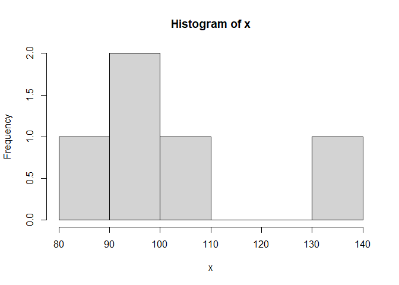

```r
hist(x)
```

Vypocitame si mean, sd aby sme dostali informacie a nasich vstupoch

```r
xmean <- mean(x)
xsd <- sd(x)
n <- length(x)
c(xmean = xmean, xsd = xsd, n = n, range = range(x)) %>% round(2)
```

```
##  xmean    xsd      n range1 range2
## 103.20  18.57   5.00  85.00 133.00
```

Pouzijeme Anderson-Darling test, ktory testuje ci H0: X pochadza z N(xmean,xsd).

```r
goftest::ad.test(x, null = pnorm, mean = mean(x), sd = sd(x), estimated = F)
```

```
##
##  Anderson-Darling test of goodness-of-fit
##  Null hypothesis: Normal distribution
##  with parameters mean = 103.2, sd = 18.566098136119
##  Parameters assumed to be fixed
##
## data:  x
## An = 0.33407, p-value = 0.9077
```

# Príklad 2 (domáci poriadok)

**Zadanie:** Bolo skúmané dodržiavanie šiestich pravidiel domáceho poriadku nájomníkmi v sociálnych bytoch pridelených mestom. Jednoduchý náhodný výber 200 bytov odhalil nasledujúce skutočnosti o počte priestupkov.

| počet_priestupkov | 0 | 1 | 2 | 3 | 4 | 5 | 6 |
| --- | --- | --- | --- | --- | --- | --- | --- |
| počet_bytov | 31-k | 51 | 70 | 32 | 9+k | 5 | 2 |

Testujte, že vzorka pochádza z rozdelenia, v ktorom počet priestupkov (zo šiestich možných priestupkov, n=6, p=?) na 1 byt je binomicky rozdelená náhodná premenná. Porovnajte teoretické a empirické početnosti graficky.

**Riešenie:**

```r
k <- 8
pocet_priestupkov <- c(0,   1,  2,  3,  4,  5,  6)
x <- c(31-k,    51, 70, 32, 9+k,    5,  2)


chisq.test(x, p=rep(1/length(x), length(x)))
```

```
##
##  Chi-squared test for given probabilities
##
## data:  x
## X-squared = 128.02, df = 6, p-value < 2.2e-16
```

Na zaklade vysledkov testu mozeme zamietnut hypotezu 0. Ze rozdelenie priestupkov na byt je binomicky nahodna premenna. Empiricka pocestnost

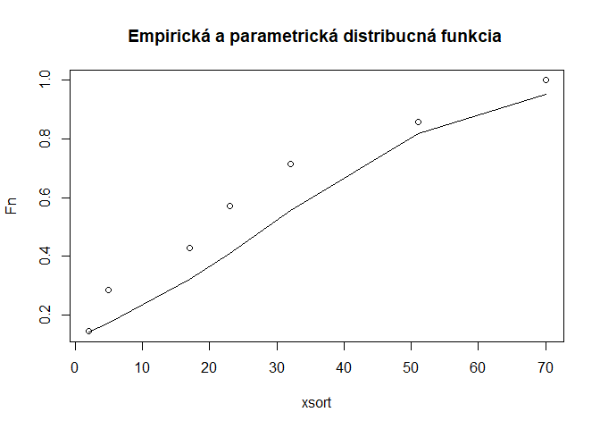

```r
xsort <- sort(x)
Fn <- rank(xsort, ties.method="max")/length(x)
Ft <- pnorm(xsort, mean=mean(x), sd=sd(x))
plot(xsort, Fn, main="Empirická a parametrická distribučná funkcia ")
lines(xsort, Ft)
```

Histogram

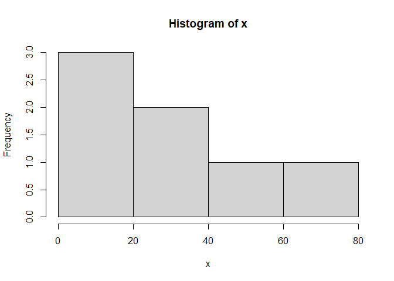

```r
hist(x)


his = hist(x)
```

```r
hranice <- his$breaks
hranice[1] <- -Inf; hranice[k+1] <- Inf
pravdep <- diff( pnorm(hranice, mean=xmean, sd=xsd) )

pocetnost <- list(
  skutocna = his$counts,
  teoreticka = pravdep*length(x)
); pocetnost
```

```
## $skutocna
## [1] 3 2 1 1
##
## $teoreticka
## [1] 2.596808e-05 2.297809e-03 6.758787e-02 6.701618e-01           NA
## [6]           NA           NA           NA
```

# Príklad 3 (životnosť žiaroviek)

**Zadanie:** Pri sledovaní životnosti 33 ks žiaroviek do dataprojektorov boli zistené výsledky (doba činnosti v jednotke času):

| 7+k | 15 | 16 | 17 | 19 | 20 | 21 | 21 | 22 | 23 | 23 |
| --- | --- | --- | --- | --- | --- | --- | --- | --- | --- | --- |
| 23 | 23 | 24 | 24 | 24 | 24 | 24 | 25 | 25 | 26 | 27 |
| 28 | 29 | 29 | 30 | 30 | 31 | 32 | 33-k | 34 | 34 | 35 |

Na hladine významnosti α=0.1 testujte tieto hypotézy, že výber je:

A = výberom z exponenciálneho rozdelenia s očakávanou hodnotou 25. Nakreslite histogram relatívnych početností a preložte #’ ním krivku hustoty-empirickú aj teoretickú.

B = výberom z normálneho rozdelenia s neznámymi parametrami. Nakreslite histogram relatívnych početností a preložte ním krivku hustoty – empirickú aj teoretickú. Nakreslite QQ graf.

**Riešenie:**

## A

```r
require('fitdistrplus')
k <- 8
x <- c(7+k, 15, 16, 17, 19, 20, 21, 21, 22, 23, 23,
       23,  23, 24, 24, 24, 24, 24, 25, 25, 26, 27,
       28,  29, 29, 30, 30, 31, 32, 33-k,   34, 34, 35)
fit1 <- fitdistr(x, "exponential")
ks.test(x, "pexp", fit1$estimate)
```

[output not shown]

Zamietame h0, rozdelenie nieje z exponencialneho rozdelenia. Histogram

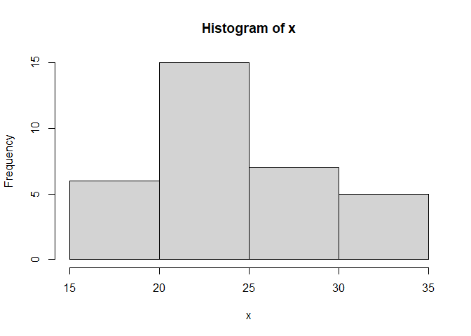

```r
his = hist(x)
```

## B

```r
xmean <- mean(x)
xsd <- sd(x)
n <- length(x)
ks.test((x - xmean) / xsd, pnorm)
```

[output not shown]

Na základe testu mozeme potvrdit ze rozdelenie pochádza z normálového rozdelenia.

# Príklad 4 (účinnosť obojkov)

**Zadanie:** Porovnali sme dĺžku účinnosti antiparazitných obojkov dvoch značiek určených pre menšie plemená psov. Merania účinnosti v dňoch sú dané tabuľkou. Na hladine významnosti *α=0.05* testujte hypotézu, že výbery sú z rovnakého rozdelenia. V prípade zamietnutia nulovej hypotézy rozhodnite, ktorú značku by ste preferovali, ak ceny obojkov oboch značiek sú rovnaké. Porovnajte aj graficky.

| obojok_A | 94 | 86 | 90 | 92 | 91 | 75+k | 86 | 87 | 97 | 91 | 92 | 97 |
| --- | --- | --- | --- | --- | --- | --- | --- | --- | --- | --- | --- | --- |
| obojok_B | 84 | 97 | 89 | 94 | 81+k | 83 | 90 | 96 | 100 | 82 |  |  |

**Riešenie:**

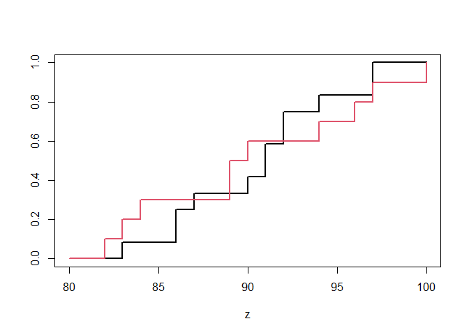

```r
k <- 8
x <- c(94   ,86 ,90 ,92 ,91 ,75+k   ,86 ,87 ,97 ,91 ,92 ,97) %>% sort()
y <- c(84   ,97 ,89 ,94 ,81+k   ,83 ,90 ,96 ,100    ,82) %>% sort()
Fx <- ecdf(x)
Fy <- ecdf(y)
z <- seq(80, 100, 1)
plot(z, Fx(z), type = "s", lwd = 2, ylab = NA)
lines(z, Fy(z), type = "s", col = 2, lwd = 2)
```

```r
ks.test(x, y, alternative = "less")
```

[output not shown]

Pri hladine vyznamosti mozeme potvrdit ze vybery su z rovnakeho rozdelenia.